# WSDA_DATA_ANALYSIS

## Data Source

This project utilizes the `WSDA_Music.db` SQLite database, a sample dataset designed for educational purposes in SQL analysis. The data originates from the LinkedIn Learning course "SQL Essential Training" (course ID: 20685933, updated around 2023), where it is provided as part of the exercise files (e.g., `Ex_Files_SQL_EssT.zip`). The database contains approximately 1,000+ entries across 11 tables, including `Track`, `Genre`, `Album`, `Artist`, `Customer`, `Invoice`, and others, simulating a music industry scenario. For accessibility, a mirrored version is available on GitHub at github.com/samaguiar/WSDA-Music-SQL, uploaded for student practice. This dataset is used here for non-commercial portfolio purposes, with full credit to its original source, LinkedIn Learning. The database is located locally at `C:\Users\USER\Downloads\sql_database\WSDA_Music.db` for this analysis.

## Genre to Track Count Visualization

### Introduction

This section focuses on visualizing the distribution of tracks across genres within the `WSDA_Music.db` SQLite database, highlighting my ability to query and represent categorical data using Python, SQL, pandas, and Matplotlib in a Jupyter Notebook. The analysis aims to identify the most prevalent music genres, providing a foundation for understanding category popularity. As part of my portfolio, this visualization showcases my skills in data aggregation and bar chart creation, with plans to apply similar techniques to diverse datasets in future projects.

### Code Cells

Below are the code cells used to query the database, process the data, and generate the visualization.

```python
%load_ext sql
```

```python
%sql sqlite:///C:/Users/USER/Downloads/sql_database/WSDA_Music.db
```

```python
%%sql
SELECT name FROM sqlite_master WHERE type='table'; --This displays all table names in WSDA MUSIC Database
```

```
 * sqlite:///C:/Users/USER/Downloads/sql_database/WSDA_Music.db
Done.
```

| name |
| --- |
| Album |
| Artist |
| Customer |
| Employee |
| Genre |
| Invoice |
| InvoiceLine |
| MediaType |
| Playlist |
| PlaylistTrack |
| Track |

```python
%%sql
PRAGMA table_info(Track); --This shows details about the track table, we shall use these details in this analysis later
```

```
 * sqlite:///C:/Users/USER/Downloads/sql_database/WSDA_Music.db
Done.
```

| cid | name | type | notnull | dflt_value | pk |
| --- | --- | --- | --- | --- | --- |
| 0 | TrackId | INTEGER | 1 | None | 1 |
| 1 | Name | NVARCHAR(200) | 1 | None | 0 |
| 2 | AlbumId | INTEGER | 0 | None | 0 |
| 3 | MediaTypeId | INTEGER | 1 | None | 0 |
| 4 | GenreId | INTEGER | 0 | None | 0 |
| 5 | Composer | NVARCHAR(220) | 0 | None | 0 |
| 6 | Milliseconds | INTEGER | 1 | None | 0 |
| 7 | Bytes | INTEGER | 0 | None | 0 |
| 8 | UnitPrice | NUMERIC(10, 2) | 1 | None | 0 |

```python
%%sql
PRAGMA table_info(Genre); --This shows details about the genre table, we shall use these details in this analysis later
```

```
 * sqlite:///C:/Users/USER/Downloads/sql_database/WSDA_Music.db
Done.
```

| cid | name | type | notnull | dflt_value | pk |
| --- | --- | --- | --- | --- | --- |
| 0 | GenreId | INTEGER | 1 | None | 1 |
| 1 | Name | NVARCHAR(120) | 0 | None | 0 |

```python
%%sql
/*
Created by: Kolawole David Adeola
Create date: 10/13/2025
Description: This sql query was designed to display the number of tracks for each genres within the database.
*/


SELECT
  g.name AS genre, --This aliases and specifies which columns would be displayed on the results pane
  COUNT(*) AS track_count --This counts the number of tracks contained in each set of genre specified by the COUNT clause
FROM
  Track AS t --This is the table containing the primary key. It is the table containing track details
JOIN
  Genre AS g --This specifies the table being joined with the Track table and aliases it as "g"
ON
  t.genreid = g.genreid --This specifies which colunm the join clause would use to connect the tables i.e genreid
GROUP BY
  g.name; -- This tells us the grouping factor, it answers the question, how would the set be grouped?
```

```
 * sqlite:///C:/Users/USER/Downloads/sql_database/WSDA_Music.db
Done.
```

| genre | track_count |
| --- | --- |
| Alternative | 40 |
| Alternative & Punk | 332 |
| Blues | 81 |
| Bossa Nova | 15 |
| Classical | 74 |
| Comedy | 17 |
| Drama | 64 |
| Easy Listening | 24 |
| Electronica/Dance | 30 |
| Heavy Metal | 28 |
| Hip Hop/Rap | 35 |
| Jazz | 130 |
| Latin | 579 |
| Metal | 374 |
| Opera | 1 |
| Pop | 48 |
| R&B/Soul | 61 |
| Reggae | 58 |
| Rock | 1297 |
| Rock And Roll | 12 |
| Sci Fi & Fantasy | 26 |
| Science Fiction | 13 |
| Soundtrack | 43 |
| TV Shows | 93 |
| World | 28 |

```python
import matplotlib
print(matplotlib.__file__)
```

```
C:\Users\USER\AppData\Local\Python\pythoncore-3.14-64\Lib\site-packages\matplotlib\__init__.py
```

```python
%matplotlib inline
```

```python
import sys
print(sys.executable)
```

```
C:\Users\USER\AppData\Local\Python\pythoncore-3.14-64\python.exe
```

```
 * sqlite:///C:/Users/USER/Downloads/sql_database/WSDA_Music.db
Done.
```

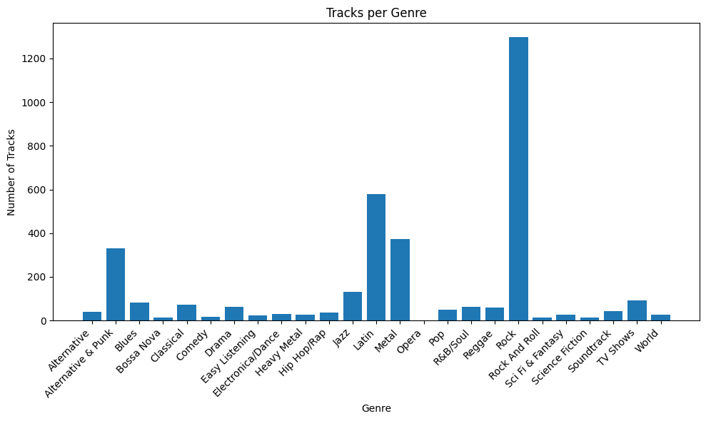

```python
%matplotlib inline
import matplotlib.pyplot as plt

result = %sql SELECT g.name AS genre, COUNT(*) AS track_count FROM Track t JOIN Genre g ON t.genreid = g.genreid GROUP BY g.name
df = result.DataFrame()

plt.figure(figsize=(10, 6))
plt.bar(df['genre'], df['track_count'])
plt.xlabel('Genre')
plt.ylabel('Number of Tracks')
plt.title('Tracks per Genre')
plt.xticks(rotation=45, ha='right')
plt.tight_layout()
plt.show()
```

### Methodology

#### Assumptions Made

It was assumed that the `genreid` column in the `Track` table consistently links to valid entries in the `Genre` table, with minimal NULL values affecting the count. Additionally, all tracks are presumed to be accurately categorized, though potential mislabeling or incomplete data was not investigated in this initial analysis.

#### Description and Query Logic

The methodology involved querying the `WSDA_Music.db` database to determine the number of tracks per genre. A SQL JOIN was executed between the `Track` and `Genre` tables using the `genreid` foreign key to associate each track with its genre name. The `COUNT(*)` function aggregated the track counts, grouped by `g.name` to ensure a single count per genre. The resulting data was converted to a pandas DataFrame for structured handling, and Matplotlib’s `plt.bar()` function was used to create the bar chart. Customizations, such as rotating x-axis labels by 45 degrees, were applied to enhance readability for genres with longer names.

### Conclusion

The "Genre to Track Count Visualization" effectively utilizes SQL joins, pandas DataFrames, and Matplotlib to analyze track distribution in the `WSDA_Music.db` database. The results confirm Rock as the dominant genre, with a clear hierarchy among categories, offering valuable insights for music industry decision-making. This project enhances my portfolio by demonstrating my proficiency in handling relational data and creating impactful visualizations, laying the groundwork for future explorations into datasets across industries like healthcare and e-commerce.